# R 03-Sampling_Ch3 Exercise Solutions

Run this code for problems 3E1-3E4.

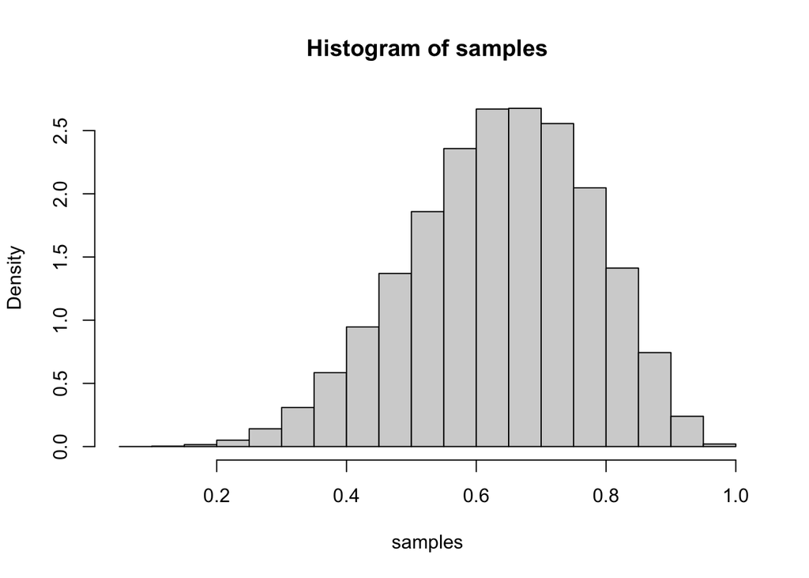

```r
p_grid <- seq( from=0 , to=1 , length.out=1000 )
prior <- rep( 1 , 1000 )
likelihood <- dbinom( 6 , size=9 , prob=p_grid )
posterior <- likelihood * prior
posterior <- posterior / sum(posterior)
set.seed(100)
samples <- sample( p_grid , prob=posterior , size=1e5 , replace=TRUE )
hist(samples,probability = TRUE)
```

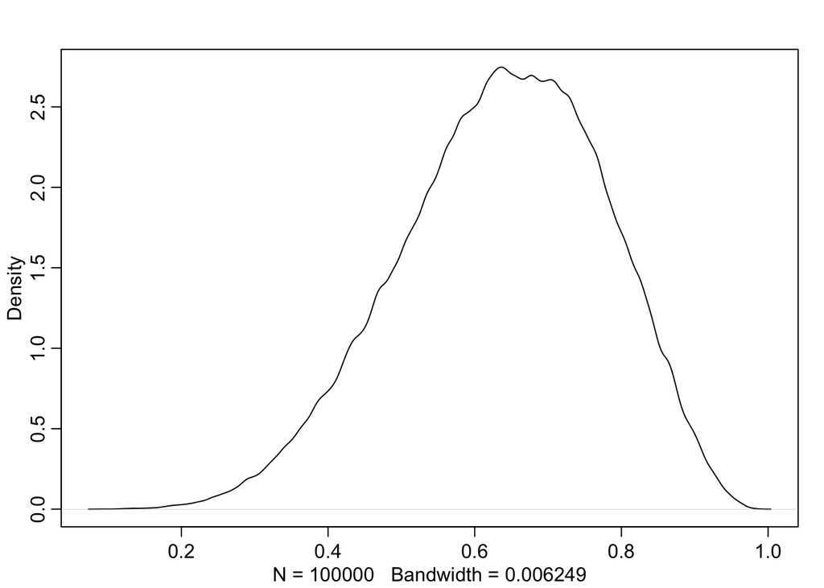

```r
library(rethinking)
dens(samples)
```

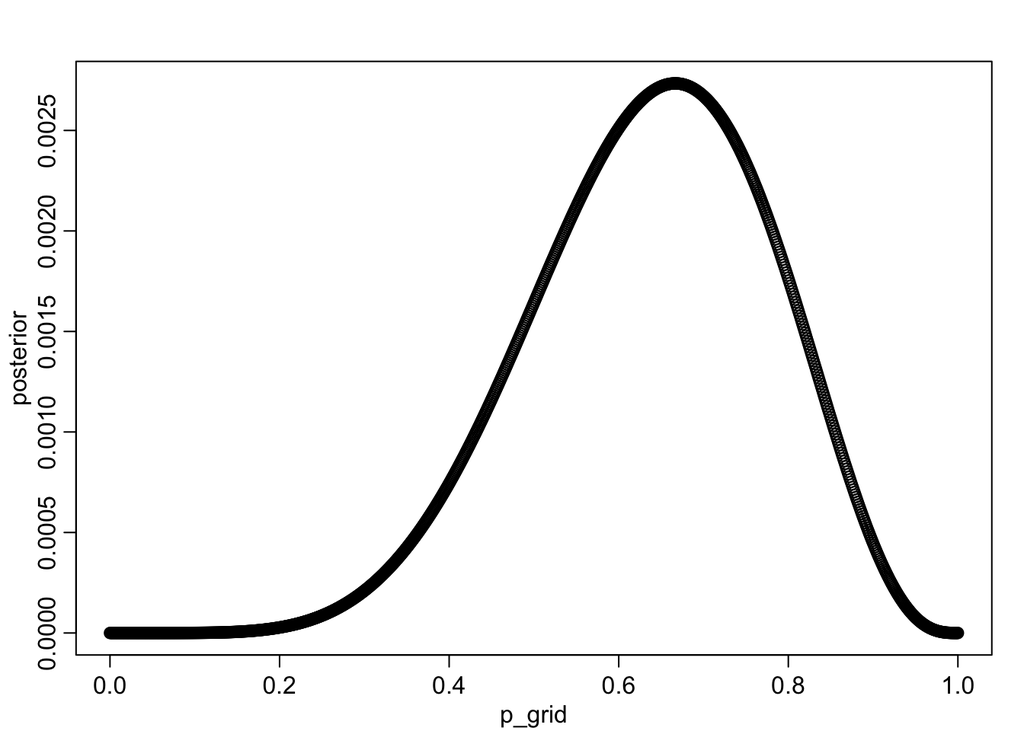

```r
plot(p_grid,posterior)
```

3E1. How much posterior probability lies below p=0.2?

```r
length(samples[samples<0.2])/length(samples) # from sampling from posterior
```

```
## [1] 0.00095
```

```r
sum( posterior[ p_grid < 0.2 ] ) # from posterior directly
```

```
## [1] 0.0008560951
```

3E2. How much posterior probability lies above p=0.8?

```r
length(samples[samples>0.8])/length(samples) # from sampling from posterior
```

```
## [1] 0.12075
```

```r
sum( posterior[ p_grid > 0.8 ] ) # from posterior directly
```

```
## [1] 0.1203449
```

3E3. How much posterior probability lies between p=0.2 and p=0.8?

```r
length(samples[samples>=0.2 & samples<=0.8])/length(samples) # from sampling from posterior
```

```
## [1] 0.8783
```

```r
sum( posterior[ p_grid>=0.2 & p_grid <= 0.8 ] ) # from posterior directly
```

```
## [1] 0.878799
```

3E4. 20% of the posterior probability lies below which value of p?

```r
quantile(samples,0.2) # from sampling from posterior
```

```
##       20%
## 0.5165165
```

```r
sum(posterior[p_grid<0.5165]) # checking agains posterior
```

```
## [1] 0.1994116
```

3M1. Suppose the globe tossing data had turned out to be 8 water in 15 tosses. Construct the posterior distribution, using grid approximation. Use the same flat prior as before.

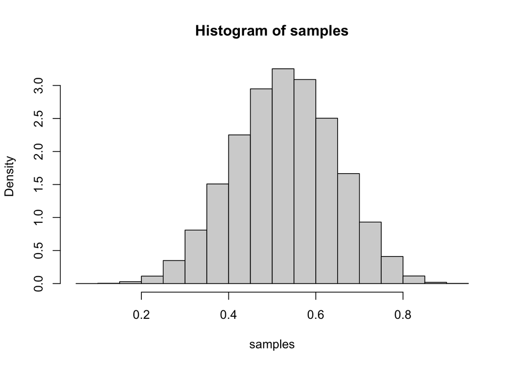

```r
p_grid <- seq( from=0 , to=1 , length.out=1000 )
prior <- rep( 1 , 1000 )
likelihood <- dbinom( 8 , size=15 , prob=p_grid )
posterior <- likelihood * prior
posterior <- posterior / sum(posterior)
set.seed(100)
samples <- sample( p_grid , prob=posterior , size=1e5 , replace=TRUE )
hist(samples,probability = TRUE)
```

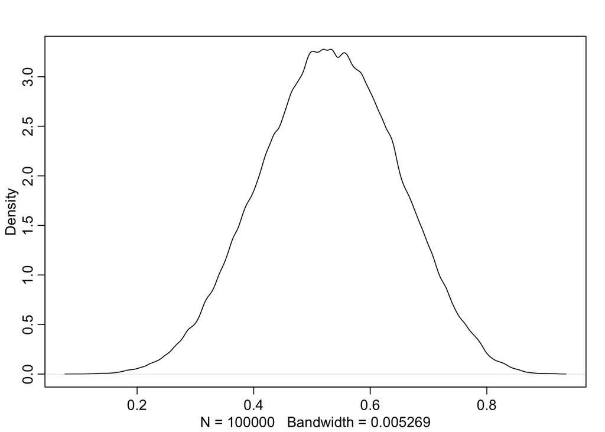

```r
library(rethinking)
dens(samples)
```

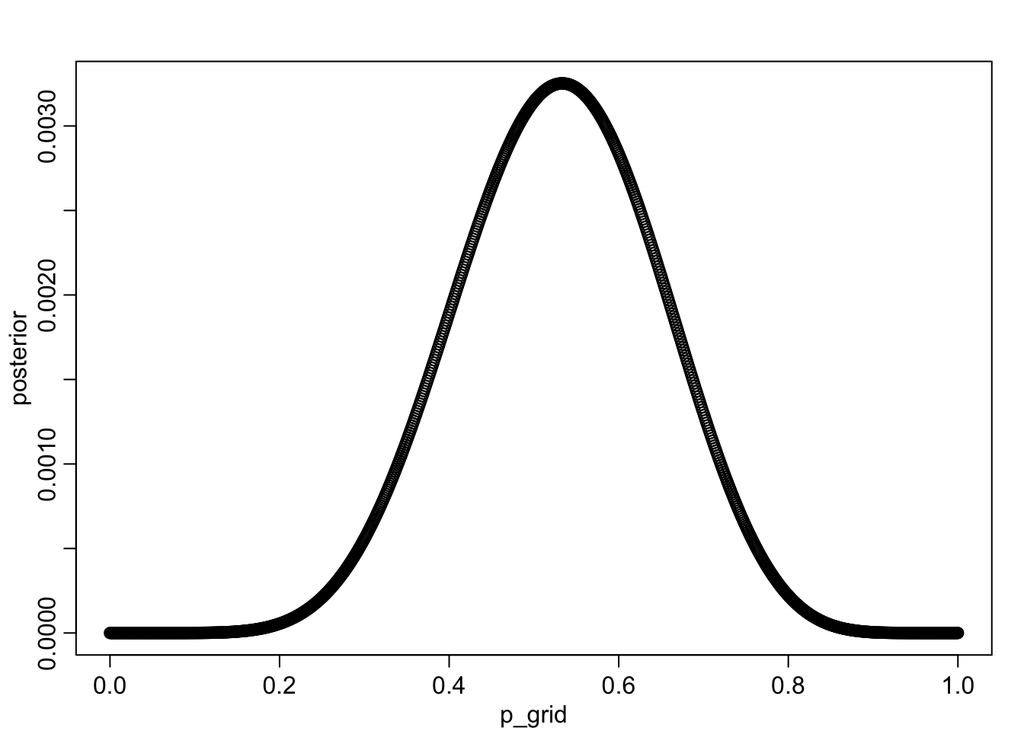

```r
plot(p_grid,posterior)
```

3M3. Construct a posterior predictive check for this model and data. This means simulate the distribution of samples, averaging over the posterior uncertainty in p. What is the probability of observing 8 water in 15 tosses?

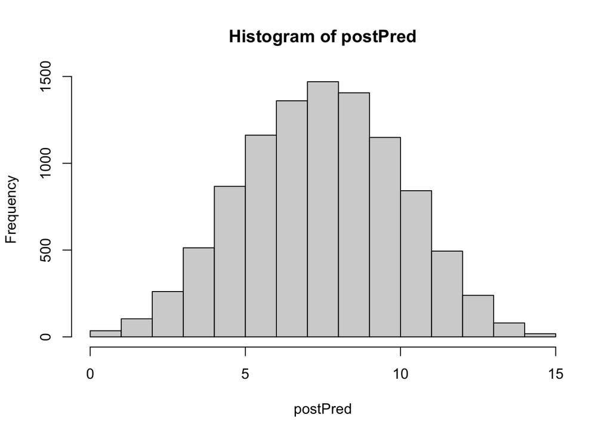

```r
p_grid <- seq( from=0 , to=1 , length.out=1000 )
prior <- rep( 1 , 1000 )
likelihood <- dbinom( 8 , size=15 , prob=p_grid )
posterior <- likelihood * prior
posterior <- posterior / sum(posterior)
set.seed(100)
samples <- sample( p_grid , prob=posterior , size=1e5 , replace=TRUE )
# hist(samples,probability = TRUE)
postPred<-rbinom(n=10000,size=15,prob=samples)

hist(postPred)
```

```r
sum(postPred==8)/length(postPred)
```

```
## [1] 0.147
```

3M4. Using the posterior distribution constructed from the new (8/15) data, now calculate the probability of observing 6 water in 9 tosses.

```r
postPred<-rbinom(n=1000000,size=9,prob=samples)
sum(postPred==6)/length(postPred)
```

```
## [1] 0.176931
```

3M5. Start over at 3M1, but now use a prior that is zero below p=0.5 and a constant above p=0.5. This corresponds to prior information that a majority of the Earth’s surface is water. Repeat each problem above and compare the inferences. What difference does the better prior make? If it helps, compare inferences (using both priors) to the true value

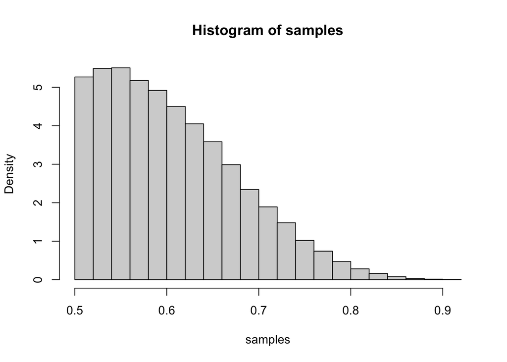

```r
p_grid <- seq( from=0 , to=1 , length.out=1000 )
prior <- rep( 1 , 1000 )
prior<-ifelse(p_grid<=0.5,0,1)
likelihood <- dbinom( 8 , size=15 , prob=p_grid )
posterior <- likelihood * prior
posterior <- posterior / sum(posterior)
set.seed(100)
samples <- sample( p_grid , prob=posterior , size=1e5 , replace=TRUE )
hist(samples,probability = TRUE)
```

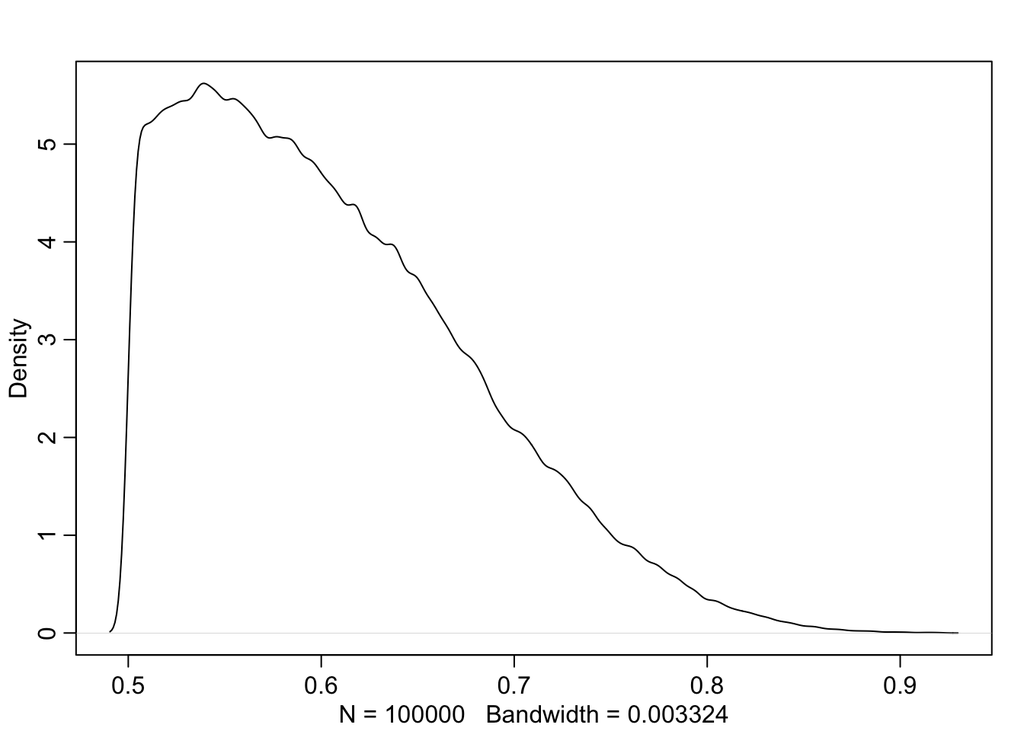

```r
library(rethinking)
dens(samples)
```

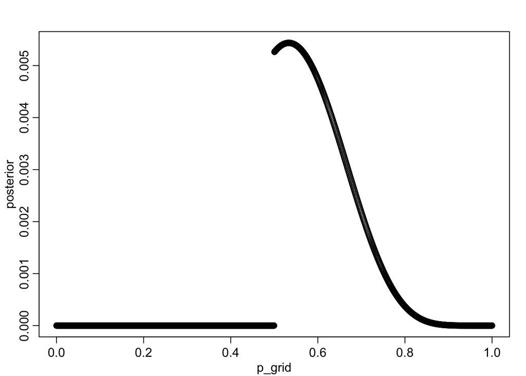

```r
plot(p_grid,posterior)
```

3M3 with new prior. Construct a posterior predictive check for this model and data. This means simulate the distribution of samples, averaging over the posterior uncertainty in p. What is the probability of observing 8 water in 15 tosses?

```r
postPred<-rbinom(n=10000,size=15,prob=samples)
sum(postPred==8)/length(postPred)
```

```
## [1] 0.1569
```

3M4 with new prior. Using the posterior distribution constructed from the new (8/15) data, now calculate the probability of observing 6 water in 9 tosses.

```r
postPred<-rbinom(n=1000000,size=9,prob=samples)
sum(postPred==6)/length(postPred)
```

```
## [1] 0.23291
```